### Read in the data

Here we read in the data and then format the *date* field to be a proper date format instead of character. Note that the usage of “straingsAsFactors=FALSE” kept the date field in character format when reading it in, which simplified the date format conversion.

```r
activity <- read.csv("activity.csv",stringsAsFactors=FALSE)
  activity$date <- as.Date(activity$date,format="%Y-%m-%d")
```

### What is the mean total number of steps taken per day?

```r
DailyTotal <- with(activity,aggregate(list(steps=steps),list(date=date),sum))
```

Now we can use that dataset to create a histogram of the total daily steps:

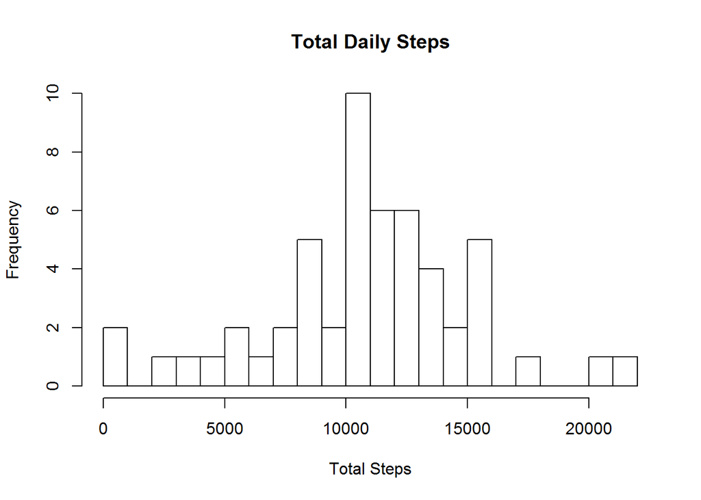

```r
hist(DailyTotal$steps, breaks=20,
      main="Total Daily Steps", xlab="Total Steps", ylab="Frequency")
```

**2. Calculate and report the the mean and median number of steps taken per day.**  
Here we can use the *summary()* function and extract just the 3rd and 4th elements of the result to get the mean and median:

```r
summary(DailyTotal$steps)[c(4,3)]
```

```
##   Mean Median
##  10770  10760
```

### What is the average daily activity pattern?

**1. Make a time series plot of the 5-minute interval (x-axis) and the average number of steps taken, averaged across all days (y-axis).**  
To do this we first aggregate our steps by interval:

```r
IntervalMeans <- with(activity,aggregate(list(meansteps=steps), list(interval=interval), mean,na.rm=T))
```

We can then make the plot of mean steps by interval:

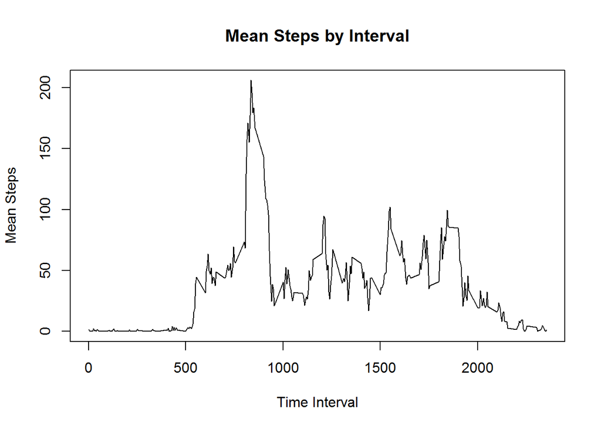

```r
with(IntervalMeans,plot(interval,meansteps,type="l",
                        main="Mean Steps by Interval",
                        ylab="Mean Steps", xlab="Time Interval"))
```

**2. Which 5-minute interval, on average across all the days in the dataset, contains the maximum number of steps?**  
Here we can simply return the row(s) that have a value of *meansteps* equal to the maximum value of *meansteps*:

```r
IntervalMeans[IntervalMeans$meansteps==max(IntervalMeans$meansteps),]
```

```
##     interval meansteps
## 104      835  206.1698
```

### Imputing missing values

**1. Calculate and report the total number of missing values in the dataset (i.e. the total number of rows with NAs).**  
This is a fairly straight-forward operation in which we count the number of rows that have a Boolean positive value:

```r
sum(is.na(activity$steps))
```

```
## [1] 2304
```

**3. Create a new dataset that is equal to the original dataset but with the missing data filled in.**  
Merge the missing set with the means and replace the NA values with the floor of the average for that interval. (We use the floor since there are no decimal steps in the original data.)

```r
impute <- merge(activity,IntervalMeans,by='interval')
  impute$steps[is.na(impute$steps)] <- floor(impute$meansteps)[is.na(impute$steps)]
impute <- impute[,-4]
```

**4. Make a histogram of the total number of steps taken each day and calculate and report the mean and median total number of steps taken per day. Do these values differ from the estimates from the first part of the assignment? What is the impact of imputing missing data on the estimates of the total daily number of steps?**  
Now aggregate to daily totals and make the histogram:

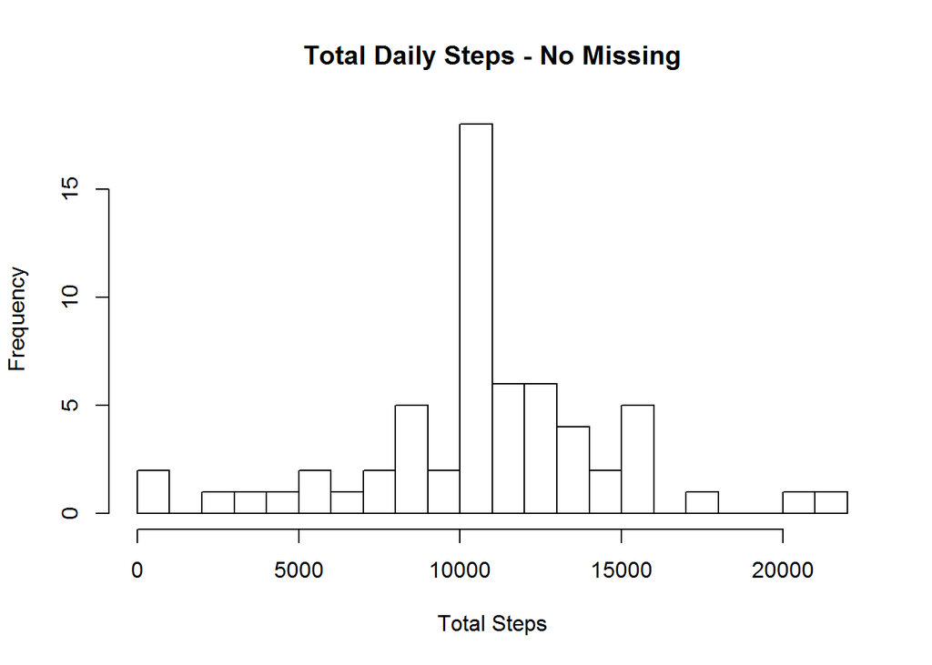

```r
DailyTotal2 <- with(impute,aggregate(list(steps=steps),list(date=date),sum))

hist(DailyTotal2$steps, breaks=20,
     main="Total Daily Steps - No Missing", xlab="Total Steps", ylab="Frequency")
```

Repeat the mean and median calculation on this dataset:

```r
summary(DailyTotal2$steps)[c(4,3)]
```

```
##   Mean Median
##  10750  10640
```

### Are there differences in activity patterns between weekdays and weekends?

**1. Create a new factor variable in the dataset with two levels – “weekday” and “weekend” indicating whether a given date is a weekday or weekend day.**  
Create factor variable for weekend or weekday:

```r
impute$daytype <- "weekday"
impute$daytype[weekdays(impute$date)=="Saturday" |
                  weekdays(impute$date)=="Sunday"]    <- "weekend"
impute$daytype <- as.factor(impute$daytype)
```

Now we can compute average steps across weekdays:

```r
IntervalMeans_daytype <- with(impute,aggregate(list(meansteps=steps),
                                             list(interval=interval,daytype=daytype),
                                             mean,na.rm=T))
```

**2. Make a panel plot containing a time series plot (i.e. type = “l”) of the 5-minute interval (x-axis) and the average number of steps taken, averaged across all weekday days or weekend days (y-axis).**  
Make a panel plot with mean steps per interval in weekdays and weekends using ggplot:

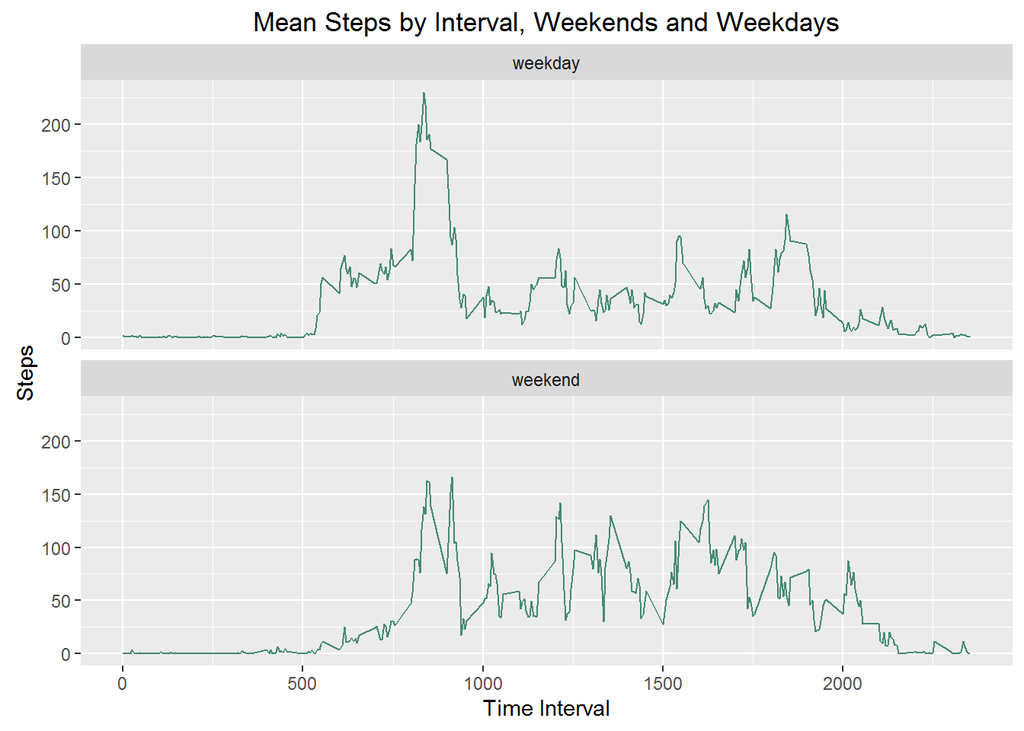

```r
library(ggplot2)
ggplot(IntervalMeans_daytype, aes(interval,meansteps)) +
       geom_path(color="aquamarine4") +
       facet_wrap(~daytype, nrow=2) +
       labs(x="Time Interval", y="Steps", title="Mean Steps by Interval, Weekends and Weekdays")
```